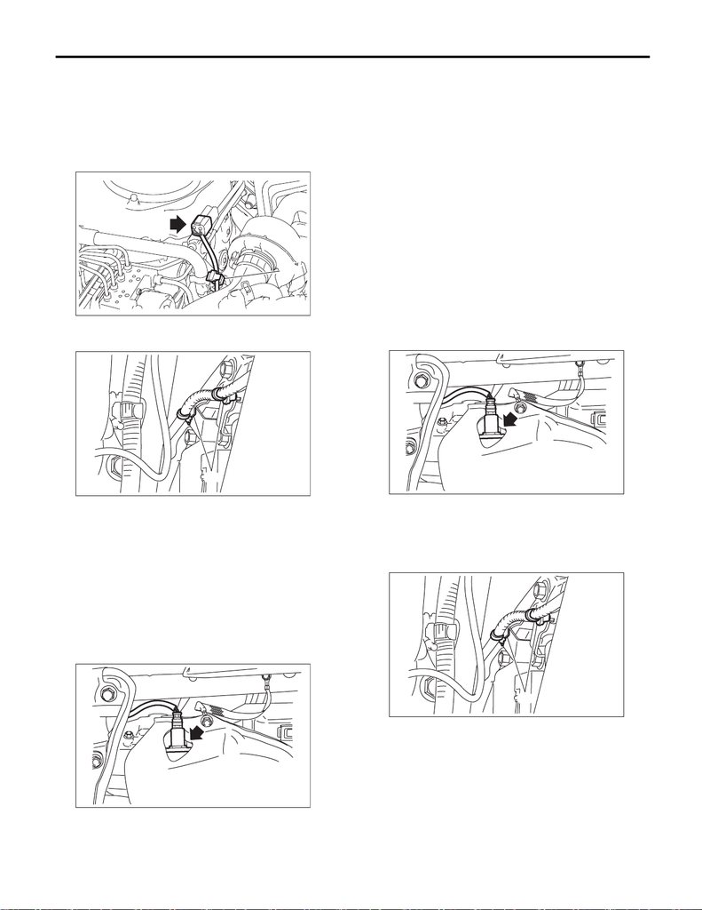

FU(STI)-52

Front Oxygen (A/F) Sensor

FUEL INJECTION (FUEL SYSTEMS)

16.Front Oxygen (A/F) Sensor

A: REMOVAL

1) Disconnect the ground cable from battery.

2) Disconnect the connector from the front oxygen

(A/F) sensor, and remove the clip (A) holding the

return hose and front oxygen (A/F) sensor harness.

3) Remove the clips (A) holding the front oxygen

(A/F) sensor harness to the engine harness stay.

4) Lift up the vehicle.

5) Remove the under cover. <Ref. to EI-21, RE-

MOVAL, Front Under Cover.>

6) Apply spray-type lubricant to the threaded por-

tion of front oxygen (A/F) sensor, and leave it for

one minute or more.

7) Remove the front oxygen (A/F) sensor.

CAUTION:

When removing the front oxygen (A/F) sensor,

wait until exhaust pipe cools, otherwise it will

damage the exhaust pipe.

B: INSTALLATION

CAUTION:

If lubricant is spilt onto the exhaust pipe, wipe it

off completely with cloth to avoid emission of

smoke or causing a fire.

1) Before installing front oxygen (A/F) sensor, ap-

ply anti-seize compound only to the threaded por-

tion of front oxygen (A/F) sensor to make the next

removal easier.

CAUTION:

Never apply anti-seize compound to the protec-

tor of front oxygen (A/F) sensor.

Anti-seize compound:

NEVER-SEEZ NSN, JET LUBE SS-30 or

equivalent

2) Install the front oxygen (A/F) sensor.

Tightening torque:

30 N·m (3.1 kgf-m, 22.1 ft-lb)

3) Install the under cover. <Ref. to EI-22, INSTAL-

LATION, Front Under Cover.>

4) Lower the vehicle.

5) Secure the front oxygen (A/F) sensor harness to

the engine harness stay using the clips (A).

FU-08328

(A)

FU-05872

(A)

FU-04607

FU-04607

FU-05872

(A)

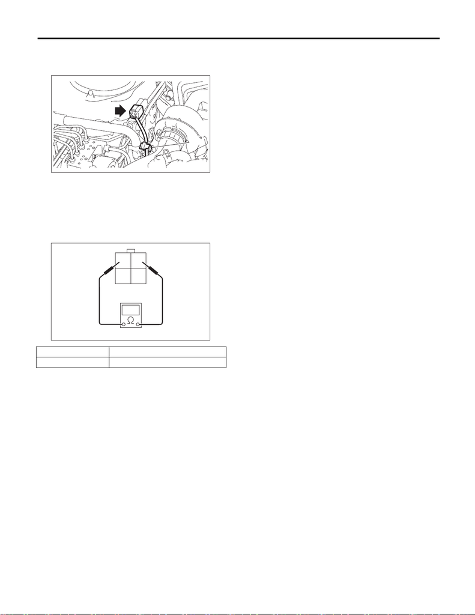

FU(STI)-53

Front Oxygen (A/F) Sensor

FUEL INJECTION (FUEL SYSTEMS)

6) Connect the connector to the front oxygen (A/F)

sensor, and secure the return hose and front oxy-

gen (A/F) sensor harness using the clip (A).

7) Connect the battery ground terminal.

C: INSPECTION

1) Check that the front oxygen (A/F) sensor has no

deformation, cracks or other damages.

2) Measure the resistance between front oxygen

(A/F) sensor terminals.

Terminal No. Standard

1 and 2 2.4±0.24 Ω (when 20°C (68°F))

FU-08328

(A)

12

3 4

FU-04072